# Exercise1_TP1

Emily Schmidt

2022-10-23

### Problem 3.4 - Laptop Sales at a London Computer Chain: Interactive Visualization

The file LaptopSales.txt is a comma-separated file with nearly 300,000 rows. ENBIS (the European Network for Business and Industrial Statistics) provided these data as part of a contest organized in the fall of 2009.  
**Scenario**: Imagine that you are a new analyst for a company called Acell (a company selling laptops). You have been provided with data about products and sales. You need to help the company with their business goal of planning a product strategy and pricing policies that will maximize Acell’s projected revenues in 2009.

```r
library(data.table) # Fast aggregation of large data sets and a fast file reader
library(lubridate) # Commute date-times
library(ggplot2) # Provides helpful commands to create complex plots from data in a data frame
library(reshape2) # Easily transform our data into whatever structure we may need
library(dplyr) # Data manipulation operations such as applying filter
library(tidyr) # Contains tools for changing the shape and hierarchy of a data set
library(caret) # Functions that attempt to streamline the process for creating predictive models
library(corrplot) # Graphical display of a correlation matrix, confidence interval or general matrix
library(lattice) # An implementation of Trellis graphics
library(tidyverse) # Transform data
library(scales) # How to normalize data
library(ggmap) # Maps visualizations
library(osmdata) # Open street maps
library(sp) # Spatial data
library(rgdal) # Needed due to error with the map
library(UpSetR) # Creates visualizations of intersecting sets using a novel matrix design, along with visualizations of several common set
library(forcats) # Need to use fct_infreq in a bar chart to sort
library(cowplot) # Arrange plots into a grid and label them
```

### Preliminary data exploratory:

```r
setwd("C:\\Users\\emann\\GSEM Master\\Data Mining\\Homework 1") # Set directory
getwd() # Check the working directory
```

```
## [1] "C:/Users/emann/GSEM Master/Data Mining/Homework 1"
```

```r
Laptops <- fread("LaptopSales_red.csv", sep = ",", header = T) # Load your data, Cereals.csv

dim(Laptops) # Get or set the dimension of the specified matrix, array or data frame
```

```
## [1] 148786     17
```

```r
head(Laptops) # Display the first n rows present in the input data frame
```

```
##        V1             Date Configuration Customer.Postcode Store.Postcode
## 1: 171289   9/20/2008 2:49           528           NW5 1SP         N3 1DH
## 2:  38634   5/30/2008 9:52           307            N6 6BU         N3 1DH
## 3: 260048  12/10/2008 9:26           235           CR0 2BW        CR7 8LE
## 4: 166045   9/15/2008 9:41           168          WC2H 9PS       SW1P 3AU
## 5: 243280 11/24/2008 23:13           517           BR3 3LA       SW12 9HD
## 6: 118859  8/12/2008 15:30           738           CR7 8RY       SW12 9HD
##    Retail.Price Screen.Size..Inches. Battery.Life..Hours. RAM..GB.
## 1:          413                   17                    4        2
## 2:          515                   15                    6        1
## 3:          315                   15                    5        2
## 4:           NA                   15                    5        1
## 5:          580                   17                    4        2
## 6:          535                   17                    6        1
##    Processor.Speeds..GHz. Integrated.Wireless. HD.Size..GB.
## 1:                    2.4                   No          300
## 2:                    2.0                  Yes           80
## 3:                    2.4                   No           80
## 4:                    2.0                  Yes          300
## 5:                    2.4                  Yes          120
## 6:                    2.0                  Yes           40
##    Bundled.Applications. customer.X customer.Y store.X store.Y
## 1:                    No     528771     186041  525109  190628
## 2:                   Yes     528281     187336  525109  190628
## 3:                   Yes     532781     166444  532714  168302
## 4:                    No     530190     181139  529902  179641
## 5:                   Yes     537350     169306  528739  173080
## 6:                    No     532498     168334  528739  173080
```

```r
View(Laptops) # Invoke a spreadsheet-style data viewer within RStudio
summary(Laptops) # Produce result summaries of the results of various model fitting functions
```

```
##        V1             Date           Configuration   Customer.Postcode
##  Min.   :     2   Length:148786      Min.   :  1.0   Length:148786
##  1st Qu.: 74275   Class :character   1st Qu.:192.0   Class :character
##  Median :148450   Mode  :character   Median :347.0   Mode  :character
##  Mean   :148742                      Mean   :379.7
##  3rd Qu.:223162                      3rd Qu.:576.0
##  Max.   :297572                      Max.   :864.0
##
##  Store.Postcode      Retail.Price   Screen.Size..Inches. Battery.Life..Hours.
##  Length:148786      Min.   :168.0   Min.   :15.00        Min.   :4.000
##  Class :character   1st Qu.:440.0   1st Qu.:15.00        1st Qu.:4.000
##  Mode  :character   Median :500.0   Median :15.00        Median :5.000
##                     Mean   :508.1   Mean   :15.81        Mean   :4.973
##                     3rd Qu.:575.0   3rd Qu.:17.00        3rd Qu.:6.000
##                     Max.   :890.0   Max.   :17.00        Max.   :6.000
##                     NA's   :6656
##     RAM..GB.     Processor.Speeds..GHz. Integrated.Wireless.  HD.Size..GB.
##  Min.   :1.000   Min.   :1.50           Length:148786        Min.   : 40.0
##  1st Qu.:1.000   1st Qu.:1.50           Class :character     1st Qu.: 40.0
##  Median :2.000   Median :2.00           Mode  :character     Median : 80.0
##  Mean   :2.101   Mean   :1.93                                Mean   :132.2
##  3rd Qu.:2.000   3rd Qu.:2.40                                3rd Qu.:120.0
##  Max.   :4.000   Max.   :2.40                                Max.   :300.0
##
##  Bundled.Applications.   customer.X       customer.Y        store.X
##  Length:148786         Min.   :512253   Min.   :164886   Min.   :517917
##  Class :character      1st Qu.:529098   1st Qu.:178716   1st Qu.:528924
##  Mode  :character      Median :530928   Median :181083   Median :529902
##                        Mean   :530748   Mean   :179890   Mean   :530644
##                        3rd Qu.:533076   3rd Qu.:182060   3rd Qu.:534057
##                        Max.   :549065   Max.   :199846   Max.   :541428
##                                                          NA's   :85
##     store.Y
##  Min.   :168302
##  1st Qu.:178440
##  Median :179641
##  Mean   :179757
##  3rd Qu.:181567
##  Max.   :190628
##  NA's   :85
```

```r
str(Laptops) # Compactly displaying the internal structure of a R object
```

```
## Classes 'data.table' and 'data.frame':   148786 obs. of  17 variables:
##  $ V1                    : int  171289 38634 260048 166045 243280 118859 249957 198058 198850 267007 ...
##  $ Date                  : chr  "9/20/2008 2:49" "5/30/2008 9:52" "12/10/2008 9:26" "9/15/2008 9:41" ...
##  $ Configuration         : int  528 307 235 168 517 738 301 301 479 472 ...
##  $ Customer.Postcode     : chr  "NW5 1SP" "N6 6BU" "CR0 2BW" "WC2H 9PS" ...
##  $ Store.Postcode        : chr  "N3 1DH" "N3 1DH" "CR7 8LE" "SW1P 3AU" ...
##  $ Retail.Price          : int  413 515 315 NA 580 535 455 465 600 392 ...
##  $ Screen.Size..Inches.  : int  17 15 15 15 17 17 15 15 17 17 ...
##  $ Battery.Life..Hours.  : int  4 6 5 5 4 6 6 6 4 4 ...
##  $ RAM..GB.              : int  2 1 2 1 2 1 1 1 1 1 ...
##  $ Processor.Speeds..GHz.: num  2.4 2 2.4 2 2.4 2 1.5 1.5 2.4 2.4 ...
##  $ Integrated.Wireless.  : chr  "No" "Yes" "No" "Yes" ...
##  $ HD.Size..GB.          : int  300 80 80 300 120 40 120 120 300 300 ...
##  $ Bundled.Applications. : chr  "No" "Yes" "Yes" "No" ...
##  $ customer.X            : int  528771 528281 532781 530190 537350 532498 533130 529390 533998 532498 ...
##  $ customer.Y            : int  186041 187336 166444 181139 169306 168334 182489 181270 168421 168334 ...
##  $ store.X               : int  525109 525109 532714 529902 528739 528739 534057 528924 528739 532714 ...
##  $ store.Y               : int  190628 190628 168302 179641 173080 173080 179682 178440 173080 168302 ...
##  - attr(*, ".internal.selfref")=<externalptr>
```

```r
head(which(is.na(Laptops))) # Function returns the positions with missing values
```

```
## [1] 743934 743958 744000 744030 744052 744088
```

```r
sum(is.na(Laptops))  # Sum the total amount of missing values in the data set
```

```
## [1] 6826
```

```r
Laptops <- na.omit(Laptops) # Remove the missing values
summary(Laptops) # Call the data set to ensure that missing values are removed
```

```
##        V1             Date           Configuration   Customer.Postcode
##  Min.   :     2   Length:142049      Min.   :  1.0   Length:142049
##  1st Qu.: 75015   Class :character   1st Qu.:192.0   Class :character
##  Median :146273   Mode  :character   Median :347.0   Mode  :character
##  Mean   :148078                      Mean   :379.1
##  3rd Qu.:222220                      3rd Qu.:574.0
##  Max.   :297572                      Max.   :864.0
##  Store.Postcode      Retail.Price   Screen.Size..Inches. Battery.Life..Hours.
##  Length:142049      Min.   :168.0   Min.   :15.00        Min.   :4.000
##  Class :character   1st Qu.:440.0   1st Qu.:15.00        1st Qu.:4.000
##  Mode  :character   Median :500.0   Median :15.00        Median :5.000
##                     Mean   :508.1   Mean   :15.81        Mean   :4.973
##                     3rd Qu.:575.0   3rd Qu.:17.00        3rd Qu.:6.000
##                     Max.   :890.0   Max.   :17.00        Max.   :6.000
##     RAM..GB.     Processor.Speeds..GHz. Integrated.Wireless.  HD.Size..GB.
##  Min.   :1.000   Min.   :1.500          Length:142049        Min.   : 40.0
##  1st Qu.:1.000   1st Qu.:1.500          Class :character     1st Qu.: 40.0
##  Median :2.000   Median :2.000          Mode  :character     Median : 80.0
##  Mean   :2.105   Mean   :1.929                               Mean   :132.2
##  3rd Qu.:2.000   3rd Qu.:2.400                               3rd Qu.:120.0
##  Max.   :4.000   Max.   :2.400                               Max.   :300.0
##  Bundled.Applications.   customer.X       customer.Y        store.X
##  Length:142049         Min.   :512253   Min.   :164886   Min.   :517917
##  Class :character      1st Qu.:529098   1st Qu.:178695   1st Qu.:528924
##  Mode  :character      Median :531026   Median :181083   Median :529902
##                        Mean   :530772   Mean   :179884   Mean   :530688
##                        3rd Qu.:533095   3rd Qu.:182060   3rd Qu.:534057
##                        Max.   :549065   Max.   :199846   Max.   :541428
##     store.Y
##  Min.   :168302
##  1st Qu.:178440
##  Median :179641
##  Mean   :179787
##  3rd Qu.:182961
##  Max.   :190628
```

One of the most important parts of analyzing your data is to conduct a preliminary exploratory review. The following points outline high-level conclusions:  
- There are 148,786 observations and 17 variables within the raw data set  
- There is information on date, configuration, customer/store location, and laptop features  
- When calling summary() and str(), we notice there are missing values and various types of variables (chr, int, and num)  
- Diving deeper into the missing values, there are 6,826 NAs. Therefore, we omit. When recalling summary(), there now should be a total of 142,049 observations that will we proceed with using throughout this analysis.

**A** - Price Questions:  
**i.** *At what price are laptops actually selling?*

```r
summary(Laptops$Retail.Price) # Produce result summaries of the Retail.Price
```

```
##    Min. 1st Qu.  Median    Mean 3rd Qu.    Max.
##   168.0   440.0   500.0   508.1   575.0   890.0
```

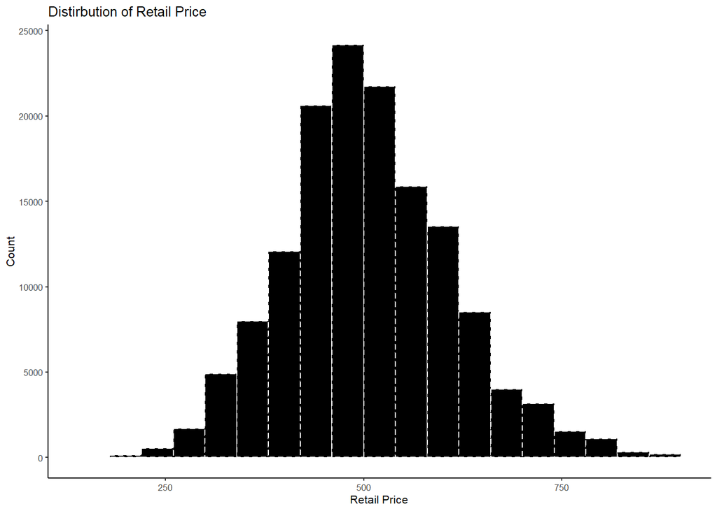

```r
# Histogram shows the distribution of the outcome variable
rp.hist <- ggplot(Laptops, aes(x = Retail.Price)) +
  geom_histogram(color="white", fill="black",binwidth = 40, linetype = "dashed") + # Graph design
  ggtitle("Distirbution of Retail Price") + # Title name
  ylab("Count") + xlab("Retail Price")  + # Label names
  theme(plot.title = element_text(size=50)) + # Title text size
  theme_classic(base_size = 8) # Elongating the graph to show all values

rp.hist
```

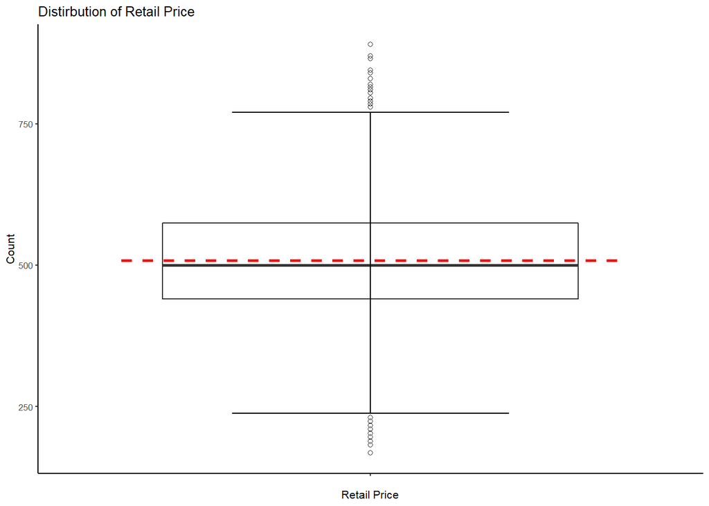

```r
#Box plot shows the distribution quartiles, min, max, median, etc.
rp.box <- ggplot(Laptops, aes(x="", y=Retail.Price)) +
  geom_boxplot(outlier.shape = 1, fill = "NA") +
  stat_boxplot(geom ='errorbar', width = .5) + # Added the horizontal bars for visualization
  ggtitle("Distirbution of Retail Price") + # Title name
  ylab("Count") + xlab("Retail Price")  + # Label names
  stat_summary(fun="mean",color="red",geom = "errorbar", aes(ymax = ..y.., ymin = ..y..), linetype = "dashed", size = 1) + # Show difference between mean and median
  theme(plot.title = element_text(size=50)) + # Title text size
  theme_classic(base_size = 8) # Elongating the graph to show all values

rp.box
```

```r
min(Laptops$Retail.Price) # Calculate minimum
```

```
## [1] 168
```

```r
max(Laptops$Retail.Price) # Calculate maximum
```

```
## [1] 890
```

```r
mean(Laptops$Retail.Price) # Calculate mean
```

```
## [1] 508.1177
```

```r
median(Laptops$Retail.Price) # Calculate median
```

```
## [1] 500
```

The retail prices range from under $200 to over $850, averaging around $508. Customers typically will purchase a laptop that is slightly under $500 though. Overall, both the histogram and the box plot assume to be normally distributed. Outside of the minimum and maximum values, one can see the numerous outliers that are present within the data.

**ii.** *Does price change with time?*

```r
Dates <- as.Date(Laptops$Date, "%m/%d/%Y") # Transform the date into M-D-Y
tab = data.frame(Dates,Laptops$Retail.Price) # Store new Date and Retail.Price

tab$Month = as.Date(cut(Dates,breaks = "month")) # Divide the Date into different ranges - months in this case
head(tab$Month) # Display the first n rows present in the input data frame
```

```
## [1] "2008-09-01" "2008-05-01" "2008-12-01" "2008-11-01" "2008-08-01"
## [6] "2008-12-01"
```

```r
tab$Week = as.Date(cut(Dates,breaks = "week",start.on.monday = F)) # Date broken into weeks, starting on Monday
head(tab$Week)
```

```
## [1] "2008-09-14" "2008-05-25" "2008-12-07" "2008-11-23" "2008-08-10"
## [6] "2008-11-30"
```

```r
tab$Days = as.Date(cut(Dates,breaks = "day",start.on.monday = F)) # Date broken into days, starting on Monday
head(tab$Days)
```

```
## [1] "2008-09-20" "2008-05-30" "2008-12-10" "2008-11-24" "2008-08-12"
## [6] "2008-12-01"
```

```r
Num = table(Laptops$Retail.Price) # Creates a table with all Retail Prices
head(Num) # Check 'Num'
```

```
##
## 168 182 189 196 203 210
##  10  11  14  15  21  31
```

```r
Laptops2 = cbind(Laptops,Num) # Mergers data together
Laptops2 <- na.omit(Laptops2) # Remove the missing values
summary(Laptops2) # Check 'Laptops2'
```

```
##        V1             Date           Configuration   Customer.Postcode
##  Min.   :     2   Length:142049      Min.   :  1.0   Length:142049
##  1st Qu.: 75015   Class :character   1st Qu.:192.0   Class :character
##  Median :146273   Mode  :character   Median :347.0   Mode  :character
##  Mean   :148078                      Mean   :379.1
##  3rd Qu.:222220                      3rd Qu.:574.0
##  Max.   :297572                      Max.   :864.0
##  Store.Postcode      Retail.Price   Screen.Size..Inches. Battery.Life..Hours.
##  Length:142049      Min.   :168.0   Min.   :15.00        Min.   :4.000
##  Class :character   1st Qu.:440.0   1st Qu.:15.00        1st Qu.:4.000
##  Mode  :character   Median :500.0   Median :15.00        Median :5.000
##                     Mean   :508.1   Mean   :15.81        Mean   :4.973
##                     3rd Qu.:575.0   3rd Qu.:17.00        3rd Qu.:6.000
##                     Max.   :890.0   Max.   :17.00        Max.   :6.000
##     RAM..GB.     Processor.Speeds..GHz. Integrated.Wireless.  HD.Size..GB.
##  Min.   :1.000   Min.   :1.500          Length:142049        Min.   : 40.0
##  1st Qu.:1.000   1st Qu.:1.500          Class :character     1st Qu.: 40.0
##  Median :2.000   Median :2.000          Mode  :character     Median : 80.0
##  Mean   :2.105   Mean   :1.929                               Mean   :132.2
##  3rd Qu.:2.000   3rd Qu.:2.400                               3rd Qu.:120.0
##  Max.   :4.000   Max.   :2.400                               Max.   :300.0
##  Bundled.Applications.   customer.X       customer.Y        store.X
##  Length:142049         Min.   :512253   Min.   :164886   Min.   :517917
##  Class :character      1st Qu.:529098   1st Qu.:178695   1st Qu.:528924
##  Mode  :character      Median :531026   Median :181083   Median :529902
##                        Mean   :530772   Mean   :179884   Mean   :530688
##                        3rd Qu.:533095   3rd Qu.:182060   3rd Qu.:534057
##                        Max.   :549065   Max.   :199846   Max.   :541428
##     store.Y            V1                  N
##  Min.   :168302   Length:142049      Min.   :   7
##  1st Qu.:178440   Class :character   1st Qu.: 106
##  Median :179641   Mode  :character   Median : 366
##  Mean   :179787                      Mean   : 821
##  3rd Qu.:182961                      3rd Qu.:1289
##  Max.   :190628                      Max.   :3546
```

```r
bymonth = aggregate(cbind(Retail.Price)~month(Dates),data = Laptops2, FUN = mean) # Creates table with Retail Price and month
bymonth # Calls the table
```

```
##    month(Dates) Retail.Price
## 1             1     486.5683
## 2             2     479.8425
## 3             3     447.4319
## 4             4     464.3391
## 5             5     455.5894
## 6             6     511.5405
## 7             7     539.8667
## 8             8     534.3172
## 9             9     502.1043
## 10           10     522.5853
## 11           11     516.0705
## 12           12     481.3256
```

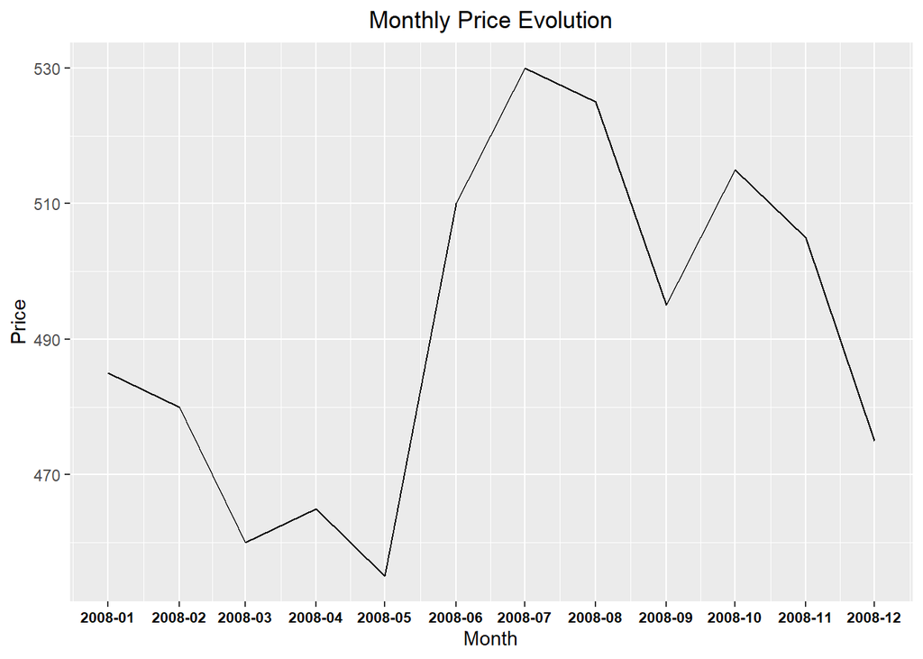

```r
Price = Laptops2$Retail.Price # Rename

# Line chart based on monthly data
ggplot(data = tab,aes(Month,Price)) +
        stat_summary(fun = median,geom = "line") +
        scale_x_date(labels=date_format("%Y-%m"),breaks = "1 month") +
        ggtitle("Monthly Price Evolution") +
        theme(plot.title = element_text(hjust = 0.5)) + # Adjust plot title
        theme(axis.text.x = element_text(face = "bold",color = "black",size = 8)) # Adjust x axis title
```

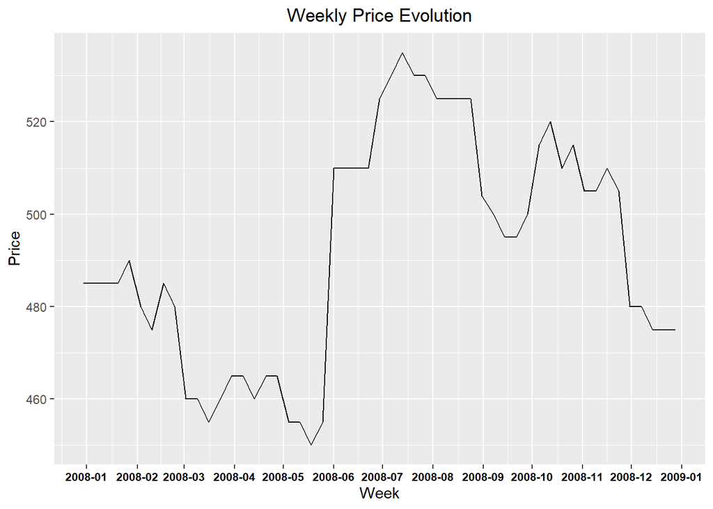

```r
# Line chart based on weekly data
ggplot(data = tab,aes(Week,Price),na.rm = T) +
        stat_summary(fun = median,geom = "line") +
        scale_x_date(labels = date_format("%Y-%m"),breaks = "1 month") +
        ggtitle("Weekly Price Evolution") +
        theme(plot.title = element_text(hjust = 0.5)) + # Adjust plot title
        theme(axis.text.x = element_text(face = "bold",color = "black",size = 8)) # Adjust x axis title
```

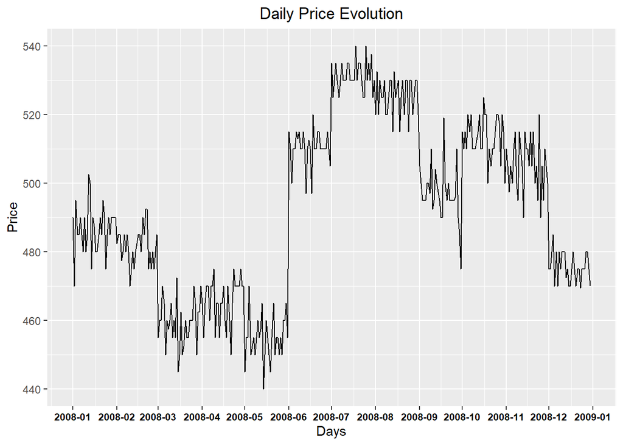

```r
# Line chart based on daily data
ggplot(data = tab,aes(Days,Price)) +
        stat_summary(fun = median,geom = "line") +
        scale_x_date(labels = date_format("%Y-%m"), breaks = "1 month") +
        ggtitle("Daily Price Evolution") +
        theme(plot.title = element_text(hjust = 0.5)) + # Adjust plot title
        theme(axis.text.x = element_text(face = "bold",color = "black",size = 8)) # Adjust x axis title
```

Yes, price changes over time. If you compare the three time-series charts above, you will notice the following:  
1. From May to July, there was a continuous increase in retail price. This could be due to a new product launching or feature that persuaded customers to purchase within that time frame.  
2. Although retail price decreased after July for a couple months, we see another slight uptick in October. Once again, we can speculate why this occurred.  
3. The first two points can be easily observed within the monthly and weekly charts. When considering daily though, you’ll notice that the highest retail price in that peak time frame of July was $540.

**iii.** *Are prices consistent across retail outlets?*

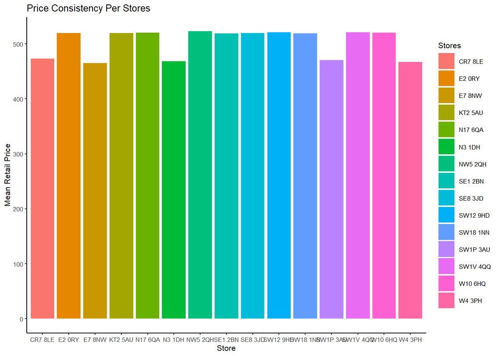

```r
# Create an aggregated table showing the average Retail Price per Store.Postcode
retail_post <- aggregate(Laptops$Retail.Price,
                    by = list(Laptops$Store.Postcode),
                    FUN = mean, na.rm = T)
names(retail_post) <- c("Stores", "MeanRetailPrice") # Assign names

# A bar plot shows the breakout of how the stores are performing
ggplot(retail_post) +
  geom_bar(aes(x = Stores , y = MeanRetailPrice, fill=Stores), na.rm = T, stat = "identity") +
  ggtitle("Price Consistency Per Stores") + # Title name
  ylab("Mean Retail Price") + xlab("Store")  + # Label names
  theme(plot.title = element_text(size=50)) + # Title text size
  theme_classic(base_size = 8) # Elongating the graph to show all values
```

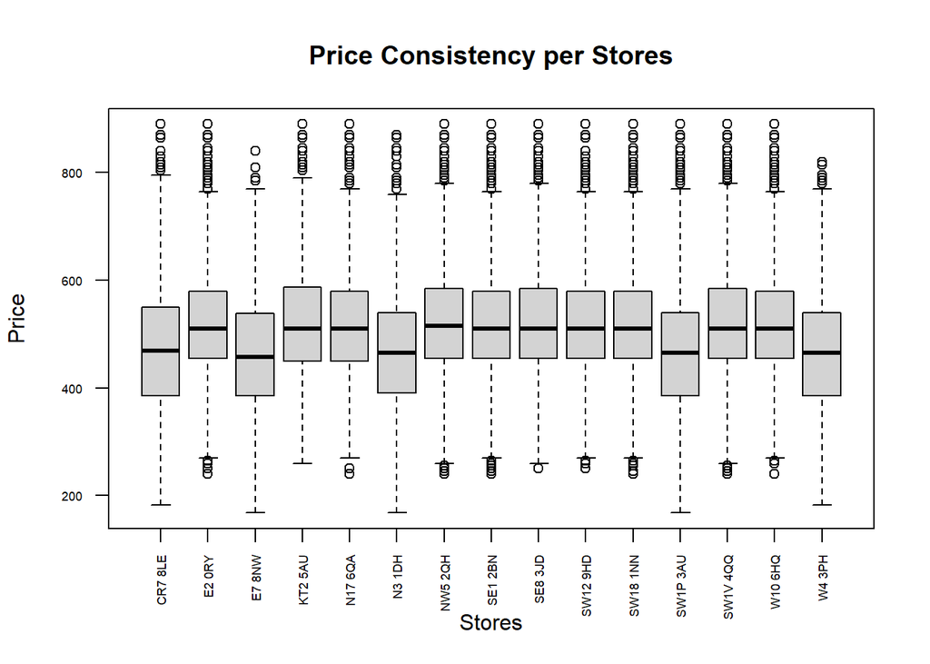

```r
# A box plot shows a little more detail about the distribution of data points, Laptops2 used from ii
boxplot(Laptops2$Retail.Price~Laptops2$Store.Postcode,data = Laptops2,
        main = "Price Consistency per Stores", xlab = "Stores", ylab ="Price",
        border = "black", las = 2, cex.axis=0.55)
```

**iv.** *How does price change with configuration?*

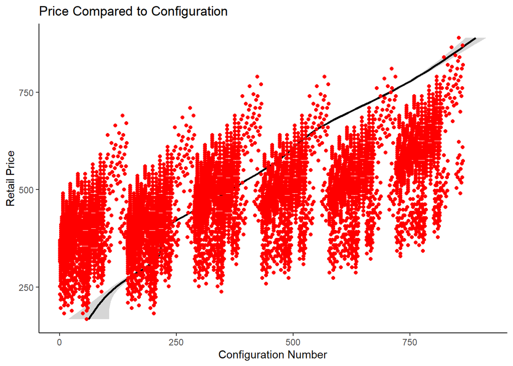

```r
# Add a trend line along with configuration points to show their relationship
config.smooth <- ggplot(Laptops) +
  geom_smooth(aes(x = Retail.Price, y = Configuration), color = "black") + # Labeled and colored
  geom_point(aes(x = Retail.Price, y = Configuration), color = "red") + # Labeled and colored
  labs(title = "Price Compared to Configuration", x = "Retail Price", y = "Configuration Number") + # Title and label names
  theme_classic()
config.smooth + coord_flip() # Flipped the chart to make it more readable
```

As the configuration number increases, we can see its direct effect on retail price in a positive direction. This graph shows how the two variables are closely related.

**B** - Location Questions:  
**i.** *Where are the stores and customers located?*

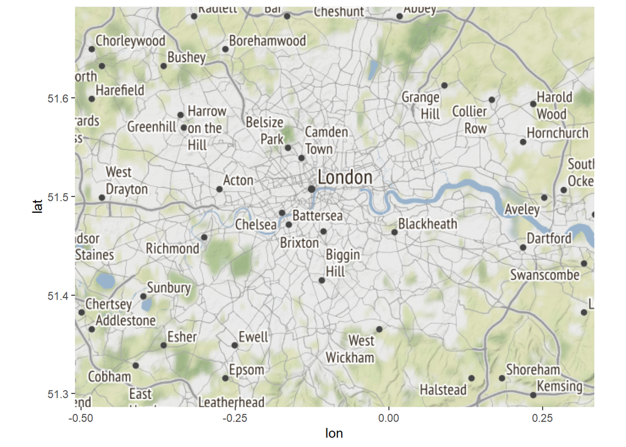

```r
# Map with open street map
map_os <- get_map(getbb("London"), source = "osm")
ggmap(map_os)
```

```r
# Transform coordinates for stores locations
colnames(Laptops)
```

```
##  [1] "V1"                     "Date"                   "Configuration"
##  [4] "Customer.Postcode"      "Store.Postcode"         "Retail.Price"
##  [7] "Screen.Size..Inches."   "Battery.Life..Hours."   "RAM..GB."
## [10] "Processor.Speeds..GHz." "Integrated.Wireless."   "HD.Size..GB."
## [13] "Bundled.Applications."  "customer.X"             "customer.Y"
## [16] "store.X"                "store.Y"
```

```r
Laptops[1:5, 14:17] # overview coordinates data
```

```
##    customer.X customer.Y store.X store.Y
## 1:     528771     186041  525109  190628
## 2:     528281     187336  525109  190628
## 3:     532781     166444  532714  168302
## 4:     537350     169306  528739  173080
## 5:     532498     168334  528739  173080
```

```r
# Select stores and its coordinates
stores_locations <- na.omit(unique(Laptops[, c("Store.Postcode", "store.X", "store.Y")]))
head(stores_locations)
```

```
##    Store.Postcode store.X store.Y
## 1:         N3 1DH  525109  190628
## 2:        CR7 8LE  532714  168302
## 3:       SW12 9HD  528739  173080
## 4:        SE1 2BN  534057  179682
## 5:       SW1V 4QQ  528924  178440
## 6:       SW1P 3AU  529902  179641
```

```r
# Create SpatialPointsDataframe
stores_locations_SP <- SpatialPointsDataFrame(
  data = data.frame(stores_locations$Store.Postcode),    # data, stores names (postcodes)
  stores_locations[, c("store.X", "store.Y")],           # coordinates, x for "Easting", y for "Northing"
  proj4string = CRS( "+init=epsg:27700" ) )              # proj4string of the coordinates, assign CRS to data

head(stores_locations_SP)
```

```
##        coordinates stores_locations.Store.Postcode
## 1 (525109, 190628)                          N3 1DH
## 2 (532714, 168302)                         CR7 8LE
## 3 (528739, 173080)                        SW12 9HD
## 4 (534057, 179682)                         SE1 2BN
## 5 (528924, 178440)                        SW1V 4QQ
## 6 (529902, 179641)                        SW1P 3AU
```

```r
class(stores_locations_SP)  # sp object
```

```
## [1] "SpatialPointsDataFrame"
## attr(,"package")
## [1] "sp"
```

```r
# Note:
## CRS, Coordinate reference systems. CRS provide a standardized way of describing locations.
## A particular CRS can be referenced by its EPSG code.
## EPSG stands for European Petroleum Survey Group. They publish a database of coordinate system
## information plus some related documents on map projections and datums.
## The EPSG codes are 4-5 digit numbers that represent CRS definitions.
## proj4string is notation used in R to describe the CRS.
## EPSG:27700 Projected coordinate system for United Kingdom (UK)
## to find code p ex just google "british national grid coordinate system epsg code"

# Transform coordinates
stores_locations_SP_LL <- spTransform(stores_locations_SP,  CRS("+init=epsg:4326")) # Data
head(stores_locations_SP_LL)
```

```
##               coordinates stores_locations.Store.Postcode
## 1  (-0.1950084, 51.60061)                          N3 1DH
## 2 (-0.09365784, 51.39824)                         CR7 8LE
## 3  (-0.1490311, 51.44209)                        SW12 9HD
## 4  (-0.0700566, 51.50019)                         SE1 2BN
## 5  (-0.1444176, 51.49022)                        SW1V 4QQ
## 6  (-0.1298972, 51.50079)                        SW1P 3AU
```

```r
#Note:
## EPSG: 4326 code is commonly used by organizations that provide GIS data for the
## entire globe or many countries. CRS used by Google Earth.

# Transform to data frame
stores_locations_LL <- data.frame(stores_locations_SP_LL)[,c(1:3)]      # keep first 3 columns
colnames(stores_locations_LL) <- c( "Store", "Longitude","Latitude")    # rename stores variables
head(stores_locations_LL)
```

```
##      Store   Longitude Latitude
## 1   N3 1DH -0.19500842 51.60061
## 2  CR7 8LE -0.09365784 51.39824
## 3 SW12 9HD -0.14903105 51.44209
## 4  SE1 2BN -0.07005660 51.50019
## 5 SW1V 4QQ -0.14441760 51.49022
## 6 SW1P 3AU -0.12989720 51.50079
```

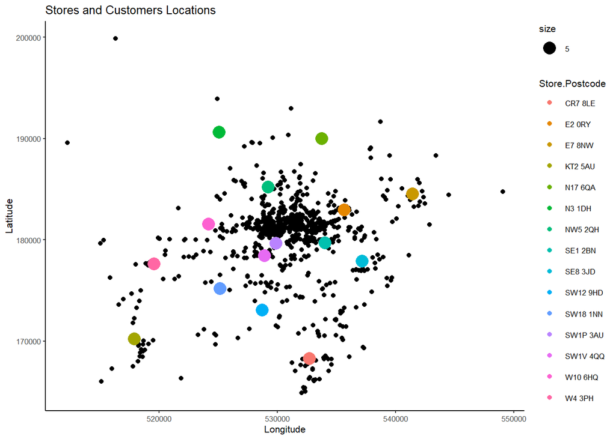

```r
#plot(Laptops$customer.X, Laptops$customer.Y,  main="Stores and Customers Locations",xlab = "Longitude",ylab = "Latitude",
#          pch = 16,cex = 0.5,col = "black",bg = "yellow") # Plot in R base with customers 'under' stores
#points(Laptops$store.X, Laptops$store.Y,pch=18, cex=2, col= "red")


store_cust <- ggplot(Laptops)+ # Overlapping customers and stores to see their locations
  geom_point(aes(customer.X, customer.Y))+
  geom_point(aes(store.X, store.Y, color = Store.Postcode,  size = 5))+
  theme(legend.position = "none") +
  ggtitle("Stores and Customers Locations") + # Title name
  ylab("Latitude") + xlab("Longitude")  + # Label names
  theme(plot.title = element_text(size=50)) + # Title text size
  theme_classic(base_size = 8) # Elongating the graph to show all values

store_cust
```

The majority of the customers are located within the center. If we compare this chart to the London map, we will see that most people are around the major city. The stores seem to surround that same area as well, but some are further away. This logically makes sense because in the real world, stores choose their location based on the poplation that surrounds that area.

**ii.** *Which stores are selling the most?*

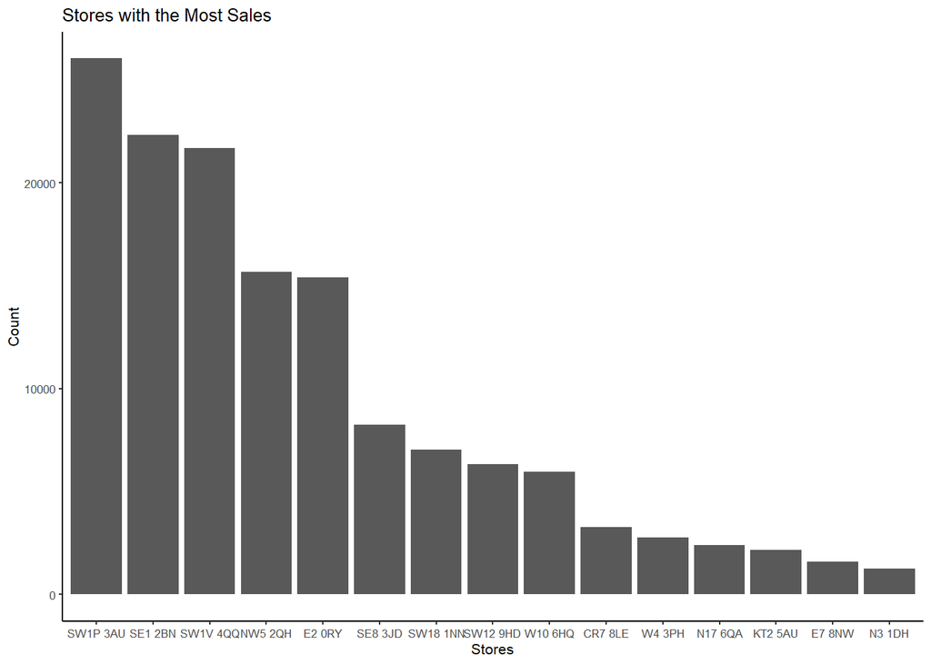

```r
L <- Laptops %>%
  ggplot(aes(x = fct_infreq(Store.Postcode))) + # Assigning frequency values to factor levels
  geom_bar() +
  labs(x = "Stores", y = "Count") + # Axis labels
  ggtitle("Stores with the Most Sales",) +  # Title name
  theme(plot.title = element_text(size=50)) + # Title size
  theme_classic(base_size = 8) # Elongating the graph to see all stores

L # Calls the histogram
```

**iii.** *How far would customers travel to buy a laptop?*

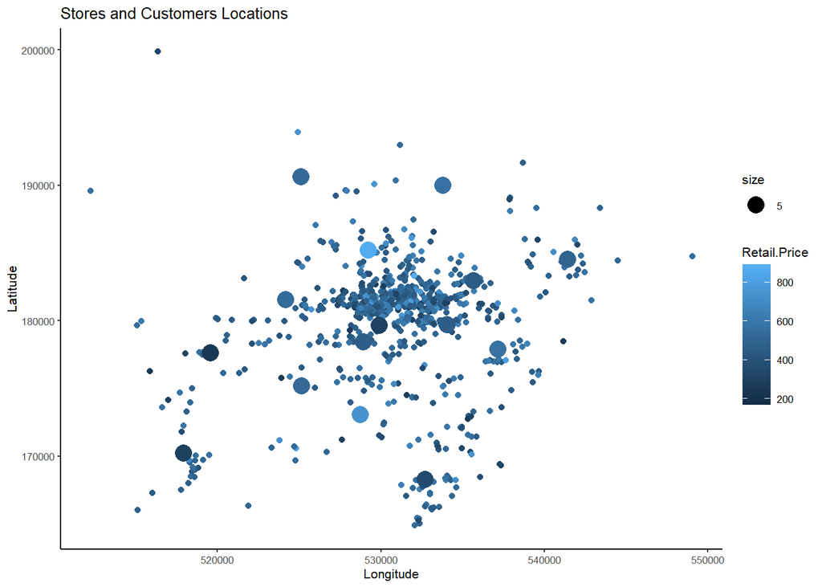

```r
#customercords$Store.Postcode <- Laptops$Store.Postcode
#customercords$Store.Postcode

#agg.medcustomers <- (stores_locations_LL[,c("Longitude","Latitude")], by=list(stores_locations_LL$Store.Postcode), FUN = mean)
#agg.medcustomers

#ggplot(agg.medcustomers,aes(x = Longitude,y = Latitude)) +
#  geom_point(aes(x = Longitude, y = Latitude, color=store_postcode, fill=store_postcode), data = stores_coord_LL, shape=2, size=3) +
#  xlab("Longitude") + ylab("Latitude") + theme_classic()

ggplot(Laptops)+ # Overlapping customers and stores to see their locations
  geom_point(aes(customer.X, customer.Y, color = Retail.Price))+
  geom_point(aes(store.X, store.Y, color = Retail.Price,  size = 5))+
  theme(legend.position = "none") +
  ggtitle("Stores and Customers Locations") + # Title name
  ylab("Latitude") + xlab("Longitude")  + # Label names
  theme(plot.title = element_text(size=50)) + # Title text size
  theme_classic(base_size = 8) # Elongating the graph to show all values
```

As my approach may not be correct, I believe that the logic may be slightly justified in finding how far customers would travel. When analyzing the chart above, the customers and stores are colored by retail price because if a store has a lower price point, that means that there are less customers going to that specific location. If that location has a higher retail price attached, you could assume that customers are willing to travel to that store instead.

**iv.** *Try an alternative way ok looking at how far customers traveled. Do this by creating a new column that computes the distance between customer and store.*

```r
Laptops2$Eucdist=sqrt((Laptops2$customer.X-Laptops2$store.X)^2+((Laptops2$customer.Y-Laptops2$store.Y)^2)) # Formula for Euclidean distance
head(Laptops2[, c(4,5,20)])  # Display the first n rows present in the input data frame
```

```
##    Customer.Postcode Store.Postcode  Eucdist
## 1:           NW5 1SP         N3 1DH 5869.481
## 2:            N6 6BU         N3 1DH 4571.526
## 3:           CR0 2BW        CR7 8LE 1859.208
## 4:           BR3 3LA       SW12 9HD 9401.723
## 5:           CR7 8RY       SW12 9HD 6054.304
## 6:          EC2A 3JL        SE1 2BN 2956.109
```

```r
summary(Laptops2$Eucdist) # Produce result summary for Eucdist
```

```
##    Min. 1st Qu.  Median    Mean 3rd Qu.    Max.
##       0    2460    3393    3710    4379   19892
```

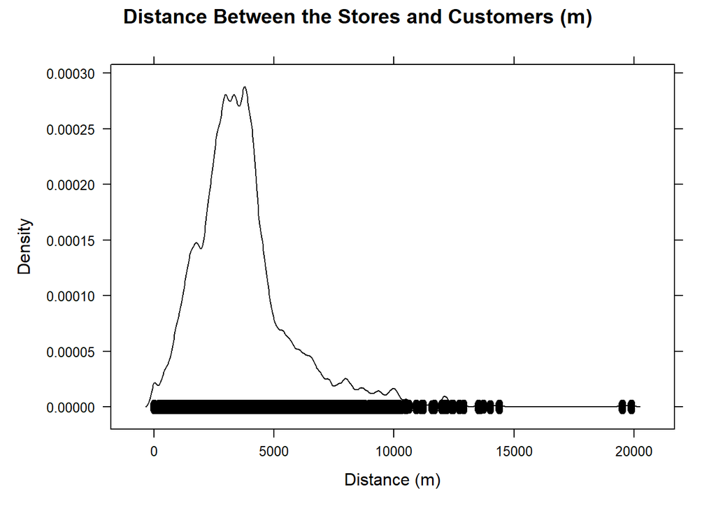

```r
Eucldist = densityplot(Laptops2$Eucdist, main="Distance Between the Stores and Customers (m)",xlab = "Distance (m)",col="black", )
Eucldist # Shows the distribution of distance
```

**C** - Revenue Questions:  
**i.** *How do the sales volume in each store relate to Acell’s revenues?*

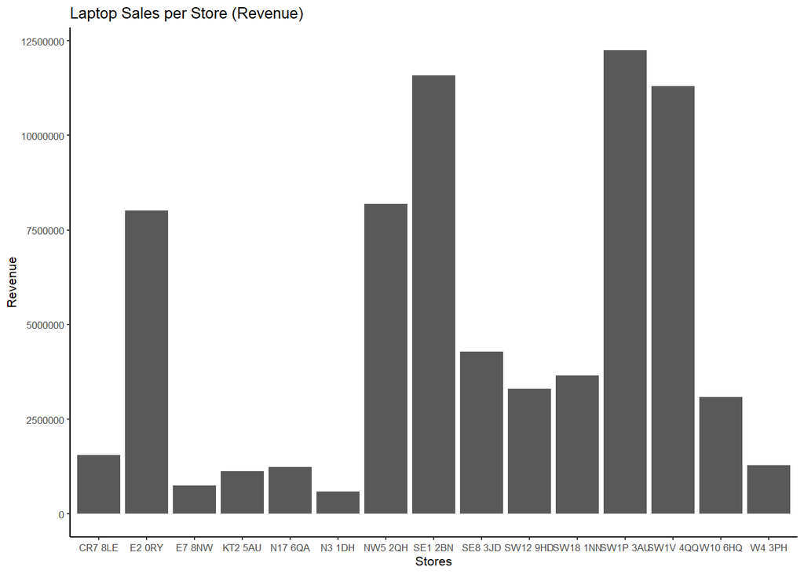

```r
# Bar chart shows top performers by Revenue
ggplot(data = Laptops,aes(x = Laptops$Store.Post,y = Retail.Price)) +
        geom_bar(stat = "identity") + # Type of chart
        ggtitle("Laptop Sales per Store (Revenue)") + # Title names
        xlab("Stores") + ylab("Revenue") + # Label names
        theme(plot.title = element_text(size=50)) + # Sets title size
        theme_classic(base_size = 8) # Elongates the graph
```

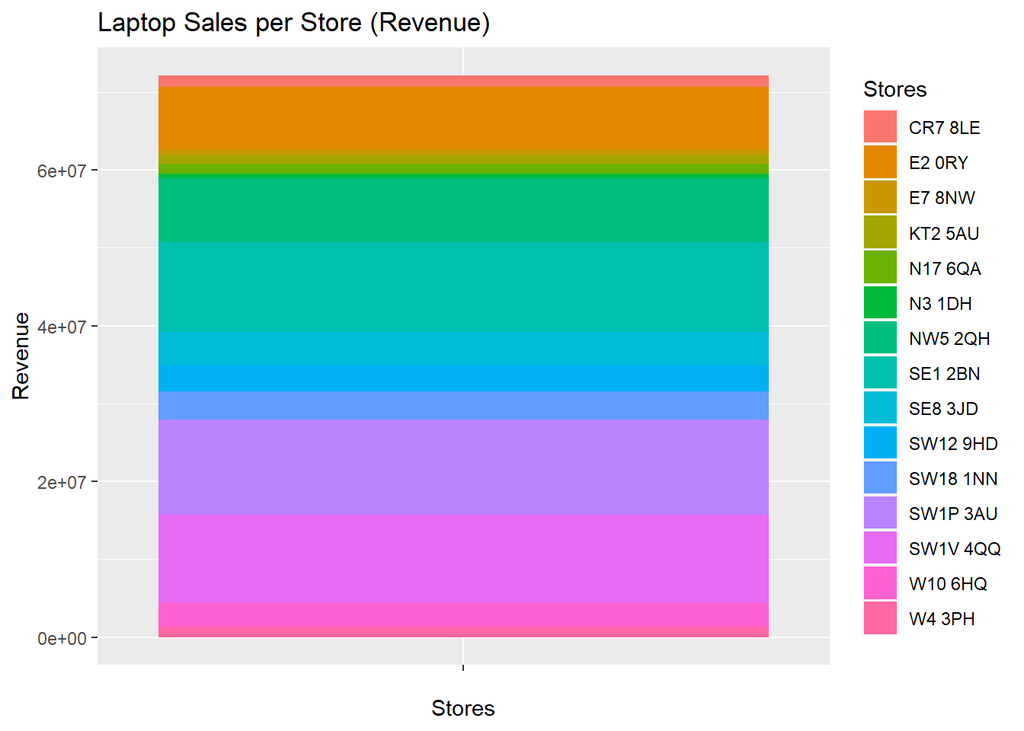

```r
revenue <- aggregate(Laptops$Retail.Price, # Aggregation without missing values
                    by = list(Laptops$Store.Postcode),
                    FUN = sum, na.rm = T)
names(revenue) <- c("Stores", "Sales") # Set the name

ggplot(revenue) +
  geom_bar(aes(x = "", y = Sales, fill=Stores),  na.rm = T, stat = "identity", width = 1) +
  labs(title = "Laptop Sales per Store (Revenue)", x="Stores", y="Revenue")
```

```r
# Create table that shows the % and total of sales per store
revenue <- mutate(revenue,  # Adds a new variable
                Store_wise_Sales_pct = Sales * 100 / sum(Sales)) %>%
  arrange(desc(Store_wise_Sales_pct))
revenue
```

```
##      Stores    Sales Store_wise_Sales_pct
## 1  SW1P 3AU 12241005           16.9595601
## 2   SE1 2BN 11589855           16.0574105
## 3  SW1V 4QQ 11300615           15.6566769
## 4   NW5 2QH  8182115           11.3360849
## 5    E2 0RY  8010470           11.0982756
## 6   SE8 3JD  4285700            5.9377140
## 7  SW18 1NN  3651725            5.0593599
## 8  SW12 9HD  3299155            4.5708843
## 9   W10 6HQ  3091830            4.2836415
## 10  CR7 8LE  1544783            2.1402524
## 11   W4 3PH  1286101            1.7818559
## 12  N17 6QA  1239960            1.7179289
## 13  KT2 5AU  1124345            1.5577476
## 14   E7 8NW   741811            1.0277578
## 15   N3 1DH   588139            0.8148497
```

**ii.** *How does this relationship depend on the configuration?*

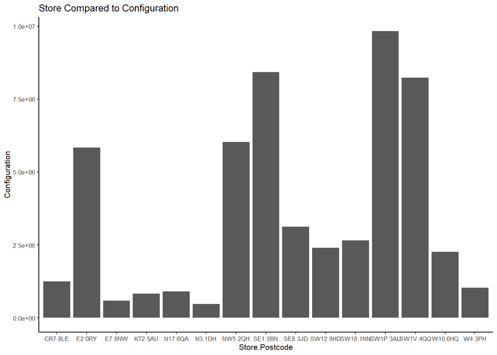

```r
ggplot(Laptops) +
  geom_bar (aes(x=Store.Postcode, y=Configuration), stat="identity")  + # Set x and y
  labs(title = "Store Compared to Configuration", x="Store.Postcode", y="Configuration") + # Add graph title
  theme_classic(base_size = 8) # Elongating the graph to show all values
```

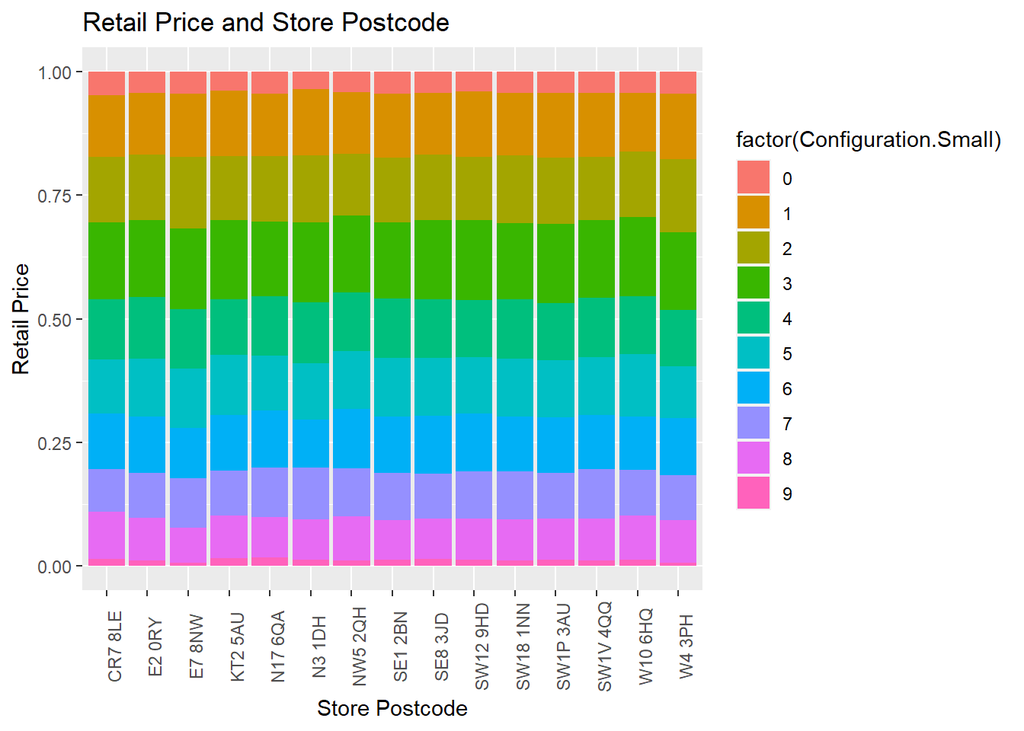

```r
sales.df <- mutate(Laptops, Configuration.Small=round(Configuration/100)) # round function and call in new variable
ggplot(sales.df) +
  geom_bar(aes(x=Store.Postcode, y=Retail.Price, fill=factor(Configuration.Small)), stat="summary",
           fun='sum', position = 'fill') +
  labs(title = "Retail Price and Store Postcode", x="Store Postcode", y="Retail Price")+
  theme(axis.text.x = element_text(angle = 90))# Labeling the graph
```

**D** - Configuration Questions:  
**i.** *What are the details of each configuration? How does this relate to price?*

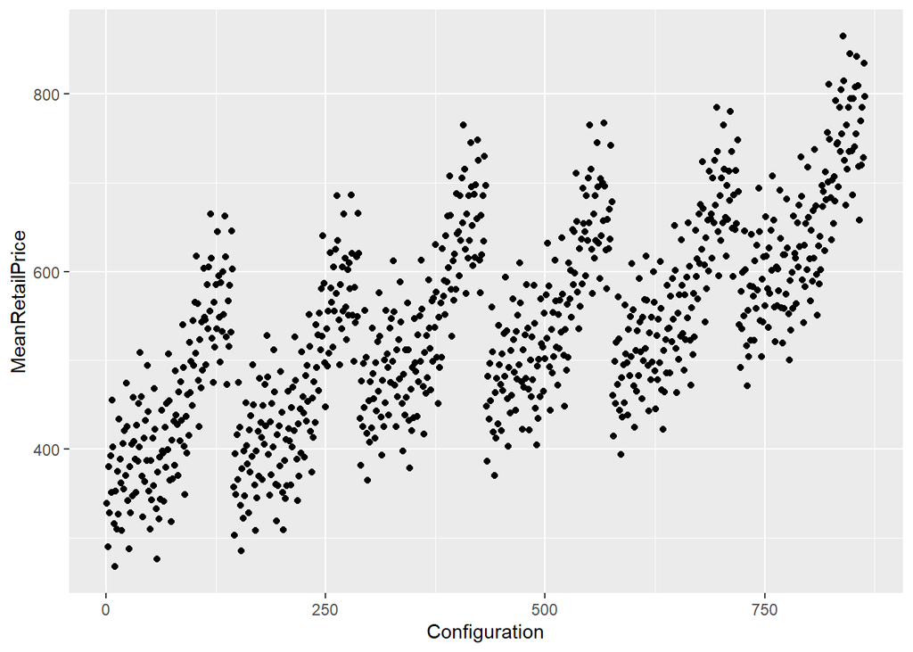

```r
conpric <- aggregate(Laptops$Retail.Price, by = list(Laptops$Configuration), FUN = mean, na.rm = T) #Aggregate and remove missing values

names(conpric) <- c("Configuration", "MeanRetailPrice") # Set name

ggplot(conpric) + geom_point(aes(x = Configuration, y = MeanRetailPrice), stat = "identity") # Create points with ggplot
```

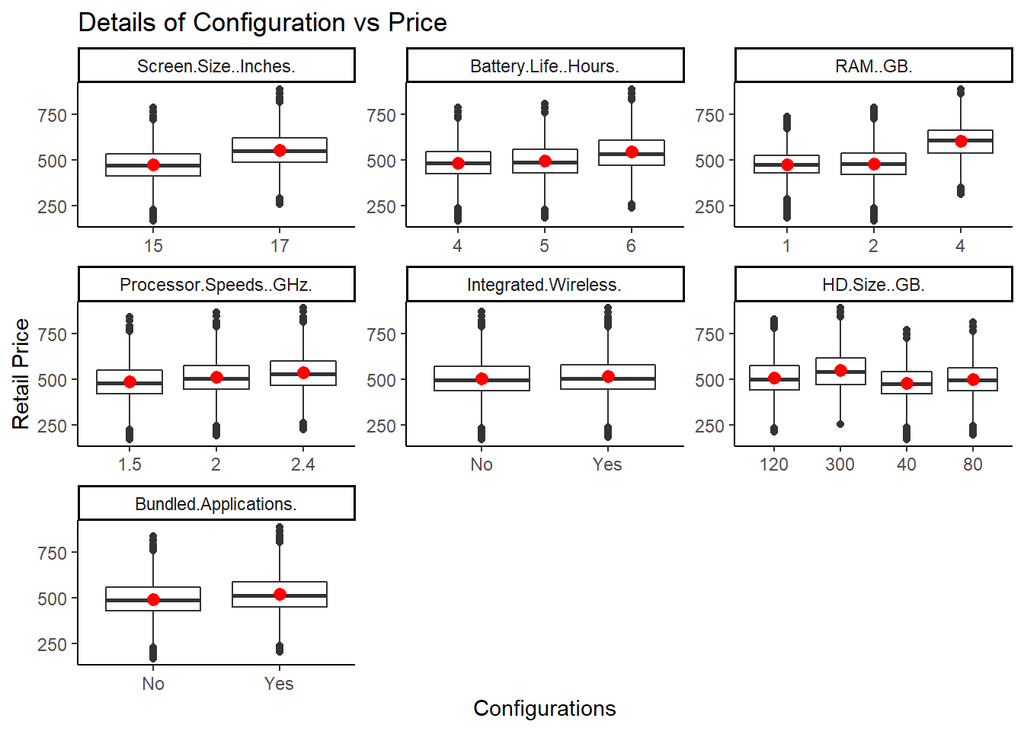

```r
price.config <- Laptops[,c(6:13)] # Call only those variables that are configured
price.config <- melt(price.config, "Retail.Price") # Organize the data - book reference

price.config.box <- ggplot(price.config, aes(x = value, y = Retail.Price)) +
  geom_boxplot() +
  stat_summary(fun = "mean", color = "red", size = .5) +
  facet_wrap(~variable, scales = "free", ncol = 3) +  # Facet wrap allows more than one variable to be shown in the same window
  labs(title = "Details of Configuration vs Price", x="Configurations", y="Retail Price") + # Label the chart
  theme_classic()

price.config.box
```

Overall, there is a positive correlation between Configuration and MeanRetailPrice as they both increase as their values become larger. We have seen this before in the Price section. If we want to review the individual details of each configuration, you will notice the following:  
- All of the configurations increase with price the better the feature is. For example, those who bought a laptop with a HD.Size.GB 300 spent more money versus if they bought one with 80.  
- The largest difference in price between the configurations appear to be with RAM.GB. The median price for RAM.GB 4 is about $600 while 1 and 2 are below $500.

**ii.** *Do all stores sell all configurations?*

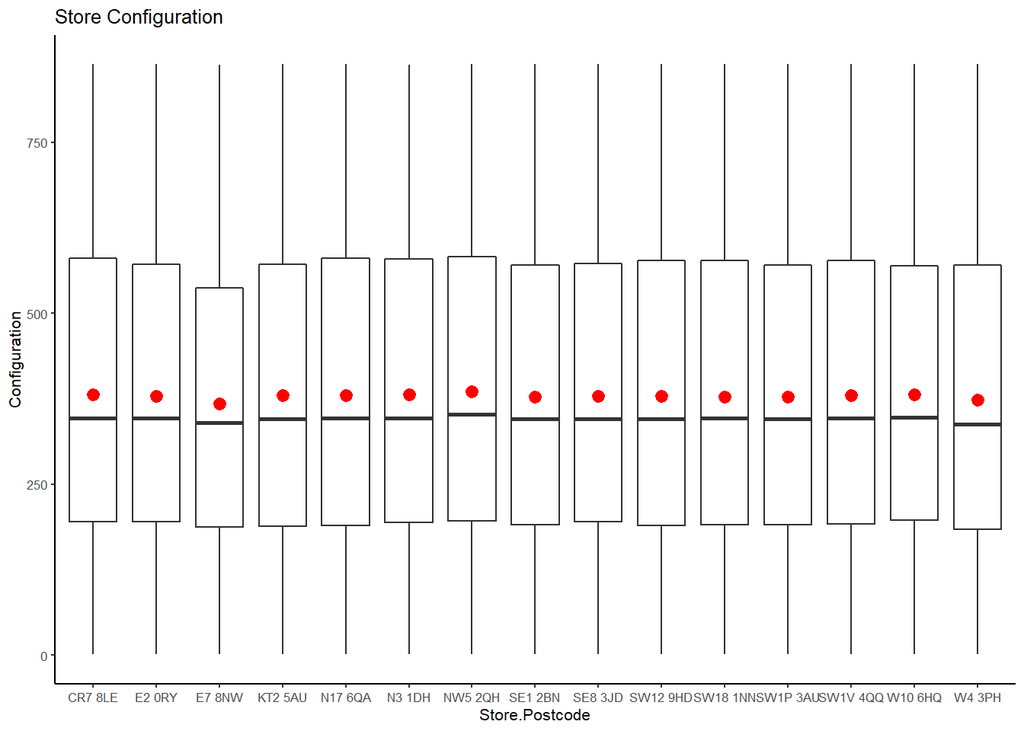

```r
ggplot(Laptops, aes(y=Configuration, x=Store.Postcode)) + # Call ggplot and variables
  geom_boxplot() + # Use box plot in ggplot
  stat_summary(fun="mean",color="red", size = .5) + # A summary statistic is used to show the mean
  labs(title = "Store Configuration") + # Title name
  theme_classic(base_size = 8) # Elongating the graph to show all values # Remove background noise
```

```r
number.of.stores <- count(Laptops %>%  # Creating a variable by grouping Store.Postcode
                            group_by(Store.Postcode) %>%
                            summarize(count=n()))

number.of.config <- count(Laptops %>% # Creating a variable by grouping Configuration
                            group_by(Configuration) %>%
                            summarize(count=n()))

count.conf <- Laptops %>%  # Creating a table to show the relationship between Store and Config.
  group_by("Store Postcode" = Store.Postcode) %>%
  summarise(Number.of.same.configuration = length(unique(Configuration))) %>%
  arrange(Number.of.same.configuration)
count.conf
```

```
## # A tibble: 15 × 2
##    `Store Postcode` Number.of.same.configuration
##    <chr>                                   <int>
##  1 N3 1DH                                    594
##  2 E7 8NW                                    669
##  3 KT2 5AU                                   741
##  4 N17 6QA                                   752
##  5 W4 3PH                                    764
##  6 CR7 8LE                                   788
##  7 SW18 1NN                                  850
##  8 W10 6HQ                                   854
##  9 SW12 9HD                                  855
## 10 SE8 3JD                                   858
## 11 E2 0RY                                    863
## 12 NW5 2QH                                   864
## 13 SE1 2BN                                   864
## 14 SW1P 3AU                                  864
## 15 SW1V 4QQ                                  864
```

According to the graphic above, some stores do not sell all configurations as they do not reach 864. It is a quite difficult to distinctively tell which stores those are. Therefore, in the table, you will notice that N3 1DH, E7 8NW, and KT2 5AU all fall under 750 types of configurations.